# Getting Started using R

May 6, 2019

# *Getting Started with R*

## Why R?

- Reproducibility
- Powerful
- Very deep community of support
- Free (*gratis*)
- Free (*libre*)

## Overview

- Commands in the console
- Vectors
- Data Frames
- Workflow
  - Scripts
  - RMarkdown notebooks
- By the end of this lesson, you should be able to do some simple data analysis in R and compose an HTML email with the results.

## Workshop materials

Everything is posted at: https://djhunter.github.io/Rworkshop

Slides can be viewed on any web browser. Keyboard shortcuts:

| shortcut | result |
| --- | --- |
| o | Toggle Overview mode (see all the slides) |
| f | Enter fullscreen mode |
| ESC | Exit fullscreen mode |
| space | next slide |
| arrows | navigate up/down/left/right |
| ? | See other shortcuts |

The **$\Rightarrow$** symbol indicates something for you to do.

# *RStudio Interface*

# *The Console*

## Use R Interactively

In the console window, you can type commands and get answers. R understands basic arithmetic.

```r
2+2
```

```
## [1] 4
```

**$\Rightarrow$** Try some basic arithmetic commands in the console window.

## Vectors

- Often you want to deal with several numbers at once.
- The `c( )` operator *combines* its contents into a *vector*.

```r
c(2,4,6,2,10)
```

```
## [1]  2  4  6  2 10
```

```r
c(2,4,6,2,10) + c(10, 20, 30, 40, 50)
```

```
## [1] 12 24 36 42 60
```

```r
c(2,4,6,2,10) * 1000
```

```
## [1]  2000  4000  6000  2000 10000
```

## Variables

- Often you want to save a vector so you can reuse it.
- The assignment operator `<-` saves a variable.

```r
joe <- c(2,4,6,2,10)
joe^2
```

```
## [1]   4  16  36   4 100
```

```r
sum(joe)
```

```
## [1] 24
```

```r
mean(joe)
```

```
## [1] 4.8
```

## Practice with variables

**$\Rightarrow$** Use the console to compute
$$\frac{1}{2^2} + \frac{1}{3^2} + \frac{1}{4^2} + \frac{1}{5^2} +\frac{1}{6^2} +\frac{1}{7^2} +\frac{1}{8^2} +\frac{1}{9^2} + \frac{1}{10^2}.$$
Start by assigning `c(2,3,4,5,6,7,8,9,10)` to a variable with a name you make up.

# *Workflow*

## Saving your work

Two ways to save your work:

- R Scripts (`foo.R` files)
  - Simple, universal
- RMarkdown documents (`foo.Rmd` files)
  - Combinations of scripts and other text
  - Can be exported (HTML, slides, PDF, etc)
- Workflow
  - Experiment in console
  - Save what worked as R Scripts or RMarkdown documents

## Make an R Script

**$\Rightarrow$** Follow the steps below to save your work from the last exercise.

1. Click on the *History* tab in the upper-right pane. Locate the lines of code that successfully computed the sum $\frac{1}{2^2} + \frac{1}{3^2} + \cdots + \frac{1}{10^2}$.
2. In the *File* menu, choose *New File > R Script*.
3. Click on the lines you located in #1, and click the *$\Leftarrow$ To Source* button.
4. Save your script to a file with a location and name you will remember. The file name should end in `.R`.
5. Test your script by clicking the *$\Rightarrow$ Source* button in the upper-left pane. The contents should execute in the console.

## Update your script

You can define a sequence of numbers using the `:` operator.

```r
2:10
```

```
## [1]  2  3  4  5  6  7  8  9 10
```

**$\Rightarrow$** Update your script so it computes $\frac{1}{2^2} + \frac{1}{3^2} + \cdots + \frac{1}{1000000^2}$. (Compare the answer to $\pi^2/6-1$.)

# *RMarkdown Documents*

## Why RMarkdown?

RMarkdown Documents allow for

- code blocks that act like the console, but can be executed inline.
- text next to code (notes, etc).
- various output formats (e.g., these slides).
- a way to provide students “worksheets” with questions and code examples.
- a way to respond to email questions with formatted output and graphs.

## **$\Rightarrow$** A Simple RMarkdown Document

1. *Save* the file simple.Rmd to a location on your computer that you will remember. (You may want to right click or two-finger click and choose *Save Link As…*.)
2. Open the file `simple.Rmd` in RStudio. There are at least 3 ways to do this:
   1. `.Rmd` files should be associated to RStudio, so clicking on them in a file manager should open them in RStudio.
   2. Use the *File…* menu in RStudio.
   3. Use the *Files* tab in the lower-right pane.
3. Try clicking the *Knit* button. If it asks you to install some packages, say “yes”.

## What happens when you knit?

- Your RMarkdown file gets saved.
- Every code chunk gets executed in a *new* environment.
- An output file (HTML, in this case) gets “knitted” together and saved in the same folder.
- The output file gets displayed.

## **$\Rightarrow$** Put your code in a chunk

4. The file `simple.Rmd` contains a *code chunk* with the command `2+2`. Notice that you can execute this code using the *$\rhd$* button in the corner of the chunk.
5. In place of the line `2+2`, insert the lines of code that you wrote for computing the sum $\frac{1}{2^2} + \frac{1}{3^2} + \cdots + \frac{1}{1000000^2}$. Be careful not to delete the lines $\verb!```{r}!$ and $\verb!```!$ that delimit the code chunk.
6. Add some text at the end of the document. Notice that blank lines in RMarkdown will create paragraph breaks in the output.
7. Check that your code worked by using the *$\rhd$* button in the corner of the chunk. Also, *Knit* your file to view the output.

# *Variables and Data Frames*

## Data Frames in R

- The basic form of data. Think spreadsheet.
- Columns have the same length, but can be different types.
- One row per observational unit.

## Built-in data sets: `iris`

```r
data("iris")
iris
```

```
##     Sepal.Length Sepal.Width Petal.Length Petal.Width    Species
## 1            5.1         3.5          1.4         0.2     setosa
## 2            4.9         3.0          1.4         0.2     setosa
## 3            4.7         3.2          1.3         0.2     setosa
## 4            4.6         3.1          1.5         0.2     setosa
## 5            5.0         3.6          1.4         0.2     setosa
## 6            5.4         3.9          1.7         0.4     setosa
## 7            4.6         3.4          1.4         0.3     setosa
## 8            5.0         3.4          1.5         0.2     setosa
## 9            4.4         2.9          1.4         0.2     setosa
## 10           4.9         3.1          1.5         0.1     setosa
## 11           5.4         3.7          1.5         0.2     setosa
## 12           4.8         3.4          1.6         0.2     setosa
## 13           4.8         3.0          1.4         0.1     setosa
## 14           4.3         3.0          1.1         0.1     setosa
```

[output cut: 136 more lines]

## Quick summary

```r
summary(iris)
```

```
##   Sepal.Length    Sepal.Width     Petal.Length    Petal.Width
##  Min.   :4.300   Min.   :2.000   Min.   :1.000   Min.   :0.100
##  1st Qu.:5.100   1st Qu.:2.800   1st Qu.:1.600   1st Qu.:0.300
##  Median :5.800   Median :3.000   Median :4.350   Median :1.300
##  Mean   :5.843   Mean   :3.057   Mean   :3.758   Mean   :1.199
##  3rd Qu.:6.400   3rd Qu.:3.300   3rd Qu.:5.100   3rd Qu.:1.800
##  Max.   :7.900   Max.   :4.400   Max.   :6.900   Max.   :2.500
##        Species
##  setosa    :50
##  versicolor:50
##  virginica :50
##
##
##
```

## Columns are vectors

Use the `$` operator to return the columns of a data frame.

```r
iris$Sepal.Length
```

```
##   [1] 5.1 4.9 4.7 4.6 5.0 5.4 4.6 5.0 4.4 4.9 5.4 4.8 4.8 4.3 5.8 5.7 5.4
##  [18] 5.1 5.7 5.1 5.4 5.1 4.6 5.1 4.8 5.0 5.0 5.2 5.2 4.7 4.8 5.4 5.2 5.5
##  [35] 4.9 5.0 5.5 4.9 4.4 5.1 5.0 4.5 4.4 5.0 5.1 4.8 5.1 4.6 5.3 5.0 7.0
##  [52] 6.4 6.9 5.5 6.5 5.7 6.3 4.9 6.6 5.2 5.0 5.9 6.0 6.1 5.6 6.7 5.6 5.8
##  [69] 6.2 5.6 5.9 6.1 6.3 6.1 6.4 6.6 6.8 6.7 6.0 5.7 5.5 5.5 5.8 6.0 5.4
##  [86] 6.0 6.7 6.3 5.6 5.5 5.5 6.1 5.8 5.0 5.6 5.7 5.7 6.2 5.1 5.7 6.3 5.8
## [103] 7.1 6.3 6.5 7.6 4.9 7.3 6.7 7.2 6.5 6.4 6.8 5.7 5.8 6.4 6.5 7.7 7.7
## [120] 6.0 6.9 5.6 7.7 6.3 6.7 7.2 6.2 6.1 6.4 7.2 7.4 7.9 6.4 6.3 6.1 7.7
## [137] 6.3 6.4 6.0 6.9 6.7 6.9 5.8 6.8 6.7 6.7 6.3 6.5 6.2 5.9
```

## Columns are vectors

Use the `$` operator to return the columns of a data frame.

```r
iris$Species
```

```
##   [1] setosa     setosa     setosa     setosa     setosa     setosa
##   [7] setosa     setosa     setosa     setosa     setosa     setosa
##  [13] setosa     setosa     setosa     setosa     setosa     setosa
##  [19] setosa     setosa     setosa     setosa     setosa     setosa
##  [25] setosa     setosa     setosa     setosa     setosa     setosa
##  [31] setosa     setosa     setosa     setosa     setosa     setosa
##  [37] setosa     setosa     setosa     setosa     setosa     setosa
##  [43] setosa     setosa     setosa     setosa     setosa     setosa
##  [49] setosa     setosa     versicolor versicolor versicolor versicolor
##  [55] versicolor versicolor versicolor versicolor versicolor versicolor
##  [61] versicolor versicolor versicolor versicolor versicolor versicolor
##  [67] versicolor versicolor versicolor versicolor versicolor versicolor
##  [73] versicolor versicolor versicolor versicolor versicolor versicolor
##  [79] versicolor versicolor versicolor versicolor versicolor versicolor
##  [85] versicolor versicolor versicolor versicolor versicolor versicolor
##  [91] versicolor versicolor versicolor versicolor versicolor versicolor
##  [97] versicolor versicolor versicolor versicolor virginica  virginica
## [103] virginica  virginica  virginica  virginica  virginica  virginica
## [109] virginica  virginica  virginica  virginica  virginica  virginica
## [115] virginica  virginica  virginica  virginica  virginica  virginica
## [121] virginica  virginica  virginica  virginica  virginica  virginica
## [127] virginica  virginica  virginica  virginica  virginica  virginica
## [133] virginica  virginica  virginica  virginica  virginica  virginica
## [139] virginica  virginica  virginica  virginica  virginica  virginica
## [145] virginica  virginica  virginica  virginica  virginica  virginica
## Levels: setosa versicolor virginica
```

## Quick box plots

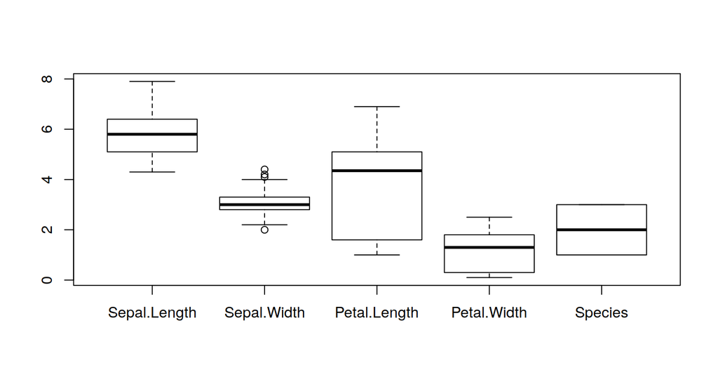

```r
boxplot(iris)
```

## Selecting rows and columns

```r
iris[1:6,1:4]
```

```
##   Sepal.Length Sepal.Width Petal.Length Petal.Width
## 1          5.1         3.5          1.4         0.2
## 2          4.9         3.0          1.4         0.2
## 3          4.7         3.2          1.3         0.2
## 4          4.6         3.1          1.5         0.2
## 5          5.0         3.6          1.4         0.2
## 6          5.4         3.9          1.7         0.4
```

## Selecting rows

```r
iris[1:6,]
```

```
##   Sepal.Length Sepal.Width Petal.Length Petal.Width Species
## 1          5.1         3.5          1.4         0.2  setosa
## 2          4.9         3.0          1.4         0.2  setosa
## 3          4.7         3.2          1.3         0.2  setosa
## 4          4.6         3.1          1.5         0.2  setosa
## 5          5.0         3.6          1.4         0.2  setosa
## 6          5.4         3.9          1.7         0.4  setosa
```

## Selecting columns

```r
iris[,1:4]
```

```
##     Sepal.Length Sepal.Width Petal.Length Petal.Width
## 1            5.1         3.5          1.4         0.2
## 2            4.9         3.0          1.4         0.2
## 3            4.7         3.2          1.3         0.2
## 4            4.6         3.1          1.5         0.2
## 5            5.0         3.6          1.4         0.2
## 6            5.4         3.9          1.7         0.4
## 7            4.6         3.4          1.4         0.3
## 8            5.0         3.4          1.5         0.2
## 9            4.4         2.9          1.4         0.2
## 10           4.9         3.1          1.5         0.1
## 11           5.4         3.7          1.5         0.2
## 12           4.8         3.4          1.6         0.2
## 13           4.8         3.0          1.4         0.1
## 14           4.3         3.0          1.1         0.1
```

[output cut: 136 more lines]

## Selecting noncontiguous columns

```r
iris[,c(2,4)]
```

```
##     Sepal.Width Petal.Width
## 1           3.5         0.2
## 2           3.0         0.2
## 3           3.2         0.2
## 4           3.1         0.2
## 5           3.6         0.2
## 6           3.9         0.4
## 7           3.4         0.3
## 8           3.4         0.2
## 9           2.9         0.2
## 10          3.1         0.1
## 11          3.7         0.2
## 12          3.4         0.2
## 13          3.0         0.1
## 14          3.0         0.1
```

[output cut: 136 more lines]

## Quick Scatterplot

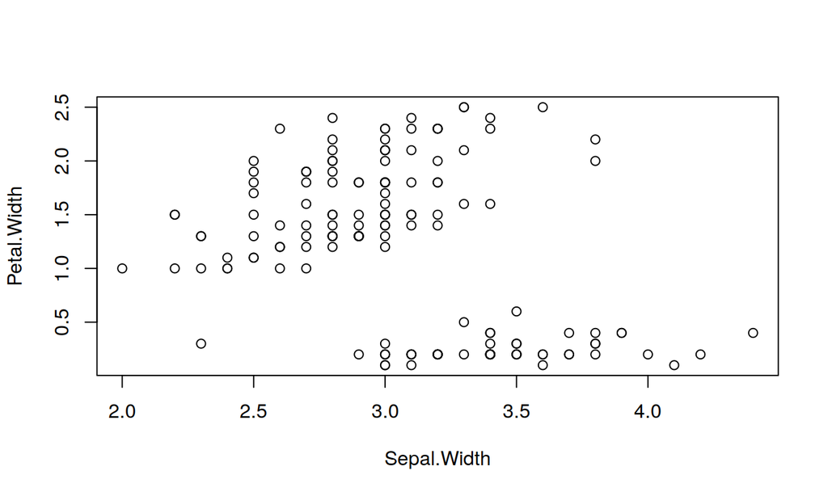

```r
plot(iris[,c(2,4)])
```

# *Explore Some data*

## **$\Rightarrow$** Write a report

1. Download the worksheet file report.Rmd and open in in RStudio.
2. Execute the first code chunk to load the `mtcars` data set and view it.
3. The other code chunks are empty, except for `TODO` comments. In the first chunk, calculate a summary of this data. In the second, plot a scatterplot of two of the variables.
4. When your report is finished, *Knit* it to HTML. Click the *Open in Browser* button to view the output in your default browser. Try copying the HTML output and pasting it into an email to yourself. (Some browsers work better than others for this task.)